# EEMB146 Lab 3 Exercise

## Exercise 4: Facet Wrap

What if you wanted to explore a numeric trend, but think site location (or another categorical context) may influence the numeric x-y relationship you see? **Facet Wrap** is a great layer to provide context to your numeric relationship, especially if you think some numeric relationships may be influenced by site or species characteristics.

**Some questions we can answer with the following code**:

- **Based on this facet wrap scatterplot, which site has the most outliers?**

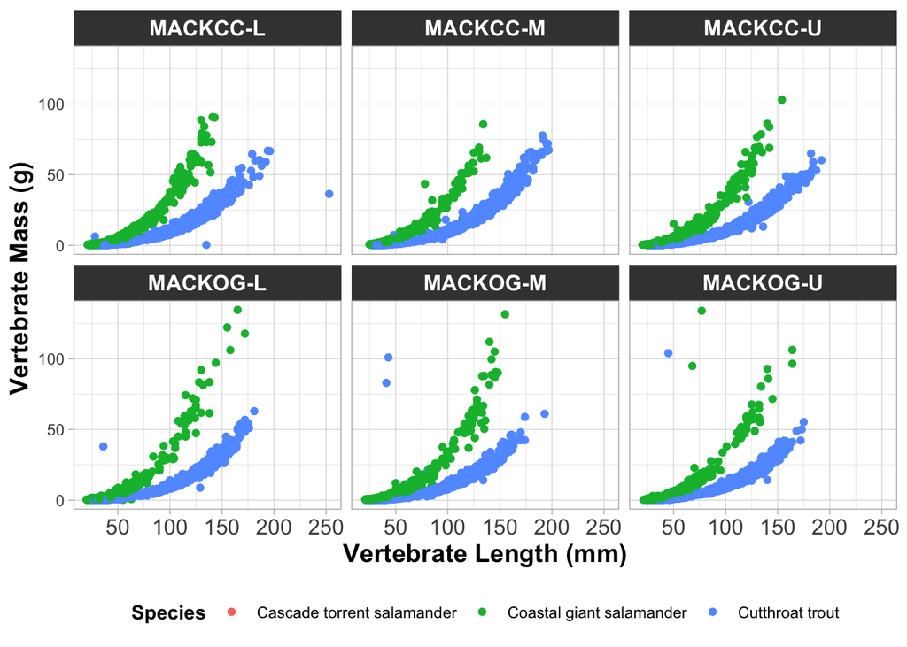

```r
vertebrates %>%
  filter(species != "NA") %>%
  ggplot(aes(x = length_1_mm, y = weight_g)) +
  geom_point(aes(color = species)) +
  facet_wrap(~sitecode) +
  theme_light() +
  labs(x = "Vertebrate Length (mm)", y = "Vertebrate Mass (g)", color = "Species") +
  theme(axis.title = element_text(size = 14, face = "bold"),
        axis.text.x = element_text(size = 12),
        legend.title = element_text(face = "bold"),
        legend.position = "bottom",
        strip.background = element_rect(fill = "grey25"),
        strip.text = element_text(face = "bold", size = 12))  # Both MACKOG-U and MACKOG-M have several outliers
```

- **What is the difference between ‘strip.background’ and ‘strip.text’?**
  - With ‘strip.background’, you can change the color of the facet wrap using the `element_rect()` function.
  - With ‘strip.text’ you can change the text of the facet wrap using the `element_text()` function.

## Exercise 5: Identify distributions

In lecture, you will hear a lot about data distributions. Data distributions are important to know because how your data is distributed ( central tendency (i.e. mean) and spread (i.e. variance)) will determine which statistical tests you can accurately run. This is a brief section with simulated data to show you what some important data distributions look like.

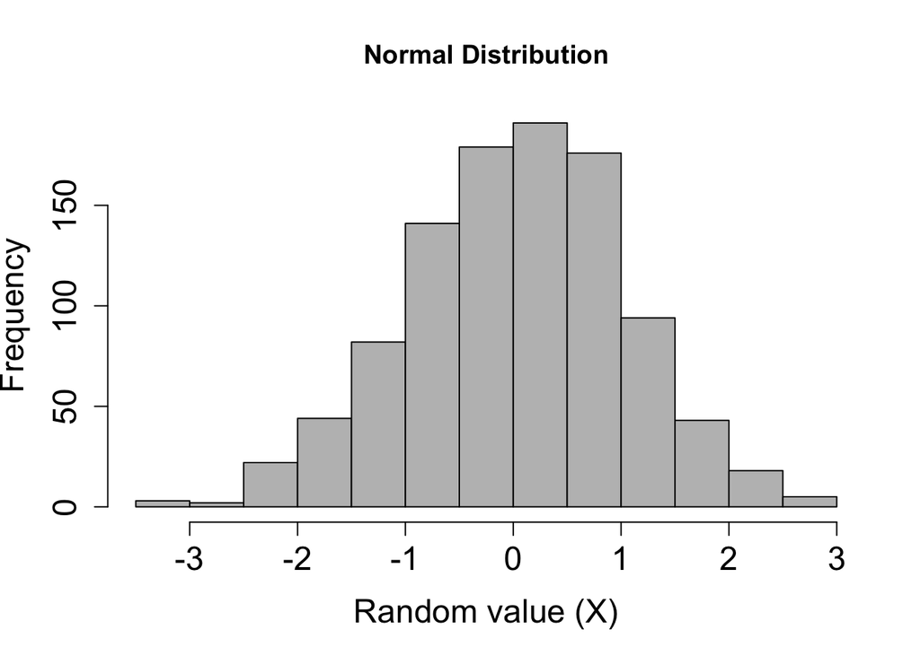

```r
# Normal distribution -- good for parametric statistical tests
rand_norms_1000 <- rnorm(n = 1000, mean = 0, sd = 1) # simulate 1000 data observations that follows normal distribution (i.e. rnorm()) with mean = 0, sd = 1
hist(rand_norms_1000, # plot a histogram of data in base R
     xlab = "Random value (X)", main = "Normal Distribution", # change labels
     col = "grey",cex.lab = 1.5, cex.axis = 1.5) # add stylistic flair
```

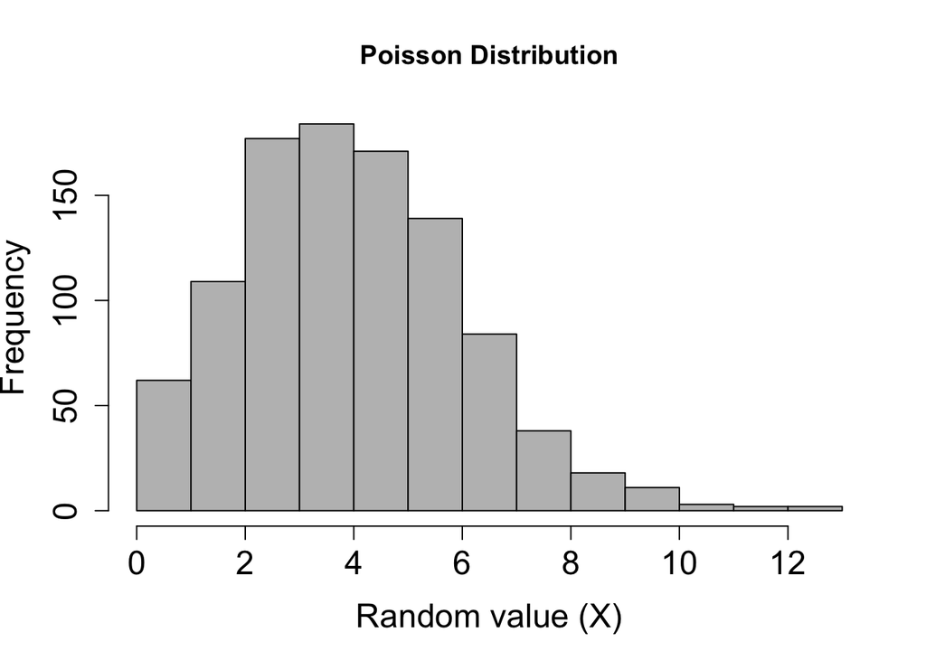

```r
# Poisson distribution -- (mostly) not good for parametric statistical tests
rand_poissons_1000 <- rpois(n = 1000, lambda = 4.5) # simulate 1000 data that follows poisson distribution (i.e. rpois()) with lambda = 4.5
hist(rand_poissons_1000, # plot a histogram of data in base R
     xlab = "Random value (X)", main = "Poisson Distribution", # change labels
     col = "grey", cex.lab = 1.5, cex.axis = 1.5) # add stylistic flair
```

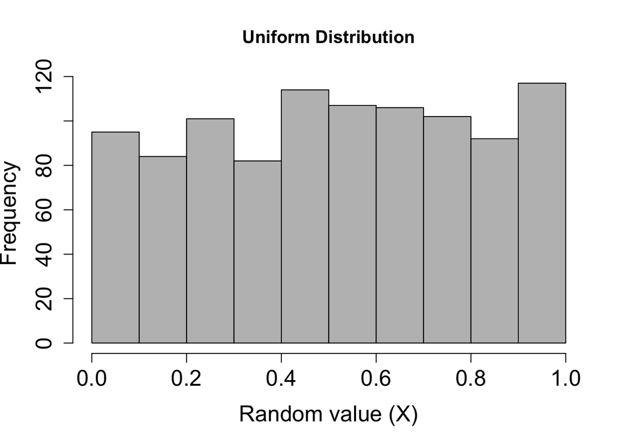

```r
# Uniform distribution -- not good for parametric statistical tests
rand_unifs_1000 <- runif(n = 1000, min = 0, max = 1) # simulate 1000 data that follows uniform distribution (i.e. runif()) bounded by 0-1
hist(rand_unifs_1000, # plot a histogram of data in base R
     xlab = "Random value (X)", main = "Uniform Distribution", # change labels
     col = "grey", cex.lab = 1.5, cex.axis = 1.5) # add stylistic flair
```